# Introduktion till praktikkursen, 15hp

SKDA50: Yrkespraktik i strategisk kommunikation  
och digitala medier HT25

studievagledare@iko.lu.se,  
nils.holmberg@iko.lu.se

## Varför praktik?

- Inblick i olika yrkesroller
- Utveckla kompetenser
- Förbereda för yrkeslivet
- Skapa kontaktyta med möjliga arbetsgivare
- Kunskaper kommer till nytta i studierna
- MEN OCKSÅ: Lär dig vad du tycker om (eller inte…)

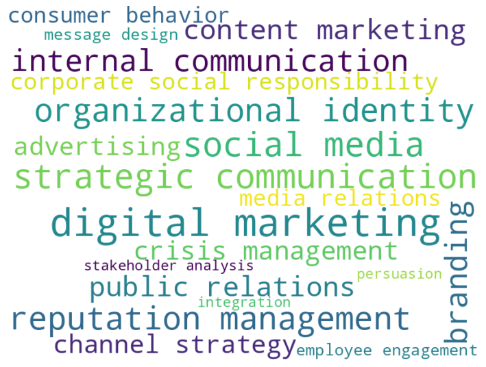

## Praktikens omfattning

```
Total days in the period: 61
Number of full weeks:     8
Number of Swedish workdays (Mon-Fri excluding holidays): 45

40 workdays * 8 hours per day full time: 320 hours internship
```

## Praktik och studier

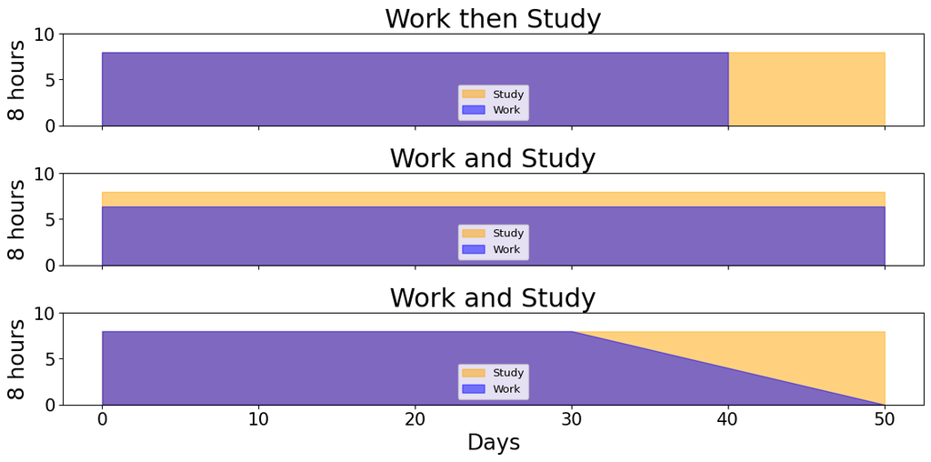

## Praktik och studier

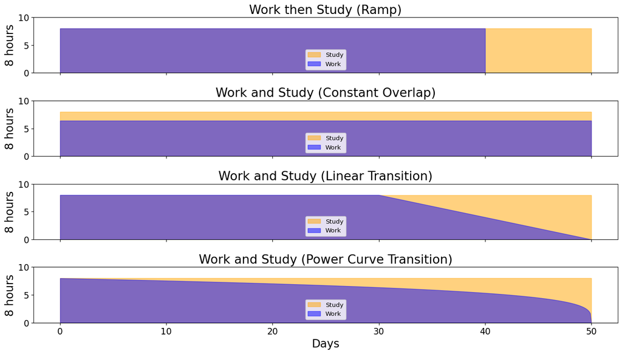

## 1. Före kursstart

- Hitta en praktikplats!
- Skriv och lämna in praktikplan på canvas
- Skriv trepartsavtal med din praktikplats
- Kolla deadlines i canvas!
- Maila avtal som pdf till kursansvarig för underskrift
- Din registrering på kursen

## Bra praktikplats?

#### 1. Före kursstart

- Relevant för yrkesområdet strategisk kommunikation, olika typer av organisationer
- Inom olika funktioner, t.ex. kommunikationsavdelning, personalavdelning, marknadsavdelning osv.
- I Sverige eller utomlands. Men (helst) inte väldigt små företag (< 3 anställda)
- Verksamhet som du vill arbeta inom efter studierna!

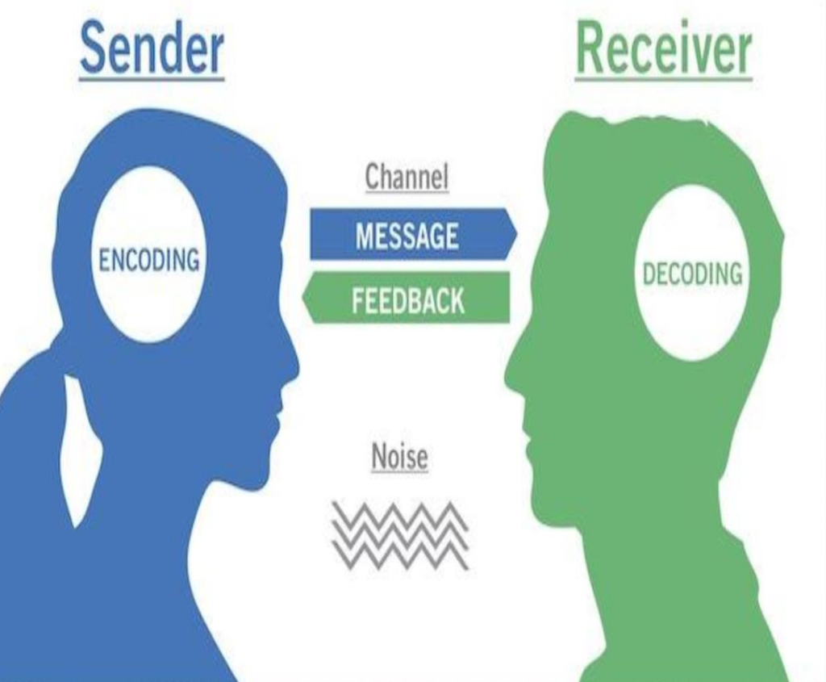

## Praktikplan

#### 1. Före kursstart

- Kontaktuppgifter (till dig och praktikplatsen)
- Presentation av praktikplatsen
- Exempel på arbetsuppgifter
- Tidsramar för din närvaro på praktikplatsen (så mycket du vet i nuläget)
- Instruktioner och inlämning på canvas (inga underskrifter behövs). Senare inlämning? Stäm av med kursansvarig!

## Trepartsavtal

#### 1. Före kursstart

- OBS! Mejlas till kursansvarig för underskrift
- Deadline = kursstart!

[figure not shown]

## 2. Under kursen

- Drop-in via zoom – boka tid med kursansvarig.
- Handledning på praktikplatsen.
- Skriv på praktikrapport. Tänk på att avsätta tid för rapporten och kom gärna överens med praktikplatsen om en plan för det!
- Praktiken ska vara minst 8 av 10 veckor = det finns 2 veckor till godo för skrivande av rapport och eventuell oväntad frånvaro, t.ex. sjukdom.

## Handledning

#### 2. Under kursen

- Nödvändigt att ha en handledare på arbetsplatsen.
- Minst tre tillfällen:
  1. Början: introduktion, praktiska frågor, avstämning av praktikplan
  2. Mitten: Hur fungerar praktiken; feedback på dina arbetsinsatser; planering av fortsatt arbete, tillstånd att använda arbetsprover (pga. sekretess etc.)
  3. Avslutning: Återkoppling och uppföljning av praktiken i sin helhet; frågor om framtiden (referens?)

## Praktikrapport

#### 2. Under kursen

- Fem delar (följ instruktioner på canvas):
  1. Arbetsplatsen och din avdelning
  2. Dina arbetsuppgifter
  3. Värdet av praktiken
  4. Din framtida yrkesbana
  5. Råd till framtida praktikanter
- Cirka 3000 ord (exkl. titelsida, innehållsförteckning och bilagor) med portfölj som bilaga

## Portfölj

#### 2. Under kursen

- Praktikrapport bilaga, Del 2: Dina arbetsuppgifter.
- Bifoga minst två representativa exempel på arbetsuppgifter du har utfört.

| Exempelvis: |
| --- |
| Texter av olika slag (pressreleaser, redaktionellt material, webbtexter etc.) |
| Beskrivningar av evenemang du har medverkat till att planera och genomföra |
| En undersökning du har genomfört |
| En kommunikationsplan |

## Kurslitteratur

#### 2. Under kursen

[figure not shown]

Falkheimer and Heide (2011)

[figure not shown]

Cunliffe (2016)

- Egen litteratur som är relaterad tillyrkesområdet och de arbetsuppgifter som utförs på praktikplatsen (cirka 200 sidor)

## 3. Kursavslutning

- Inlämning av praktikrapport ca en vecka innan seminarium
- Slutseminarium för erfarenhetsutbyte (anordnas via zoom)
- Inlämning av praktikintyg i slutet av terminen
- Examinationer i canvas och slutbetyg i LADOK
- Kolla deadlines i canvas!

## Praktikintyg

#### 3. Kursavslutning

- Inlämning av praktikintyg i slutet av terminen:
  1. Laddas ner från canvas
  2. Fyll i studentens personuppgifter
  3. Intyg på 320 timmars praktik
  4. Skrivs under av praktikhandledare

[figure not shown]

## Examination

#### 3. Kursavslutning

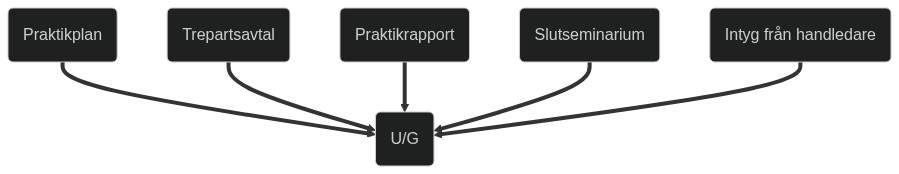

## Next steps

**Canvas**

- Praktikplan
- Trepartsavtal

**Slides**

- https://cca-cce.github.io/osm-comm/web/edu/skda50-komb27.html

**References**

Cunliffe, Ann L. 2016. “‘On Becoming a Critically Reflexive Practitioner’ Redux: What Does It Mean to Be Reflexive?” *Journal of Management Education* 40 (6): 740–46.

Falkheimer, Jesper, and Mats Heide. 2011. “Strategisk Kommunikation: Forskning Och Praktik.”